# case studies

### Load library packages

```r
library(tidyverse)
library(skimr)
library(tidymodels)
library(corrplot)
```

## 5.14 Case studies

https://jhudatascience.org/tidyversecourse/model.html#case-studies-4

### Predicting Annual Air Pollution (case study 1)

#### the data

There are 48 predictors with values for 876 monitors (observations). The data comes from the US Environmental Protection Agency (EPA), the National Aeronautics and Space Administration (NASA), the US Census, and the National Center for Health Statistics (NCHS).

https://jhudatascience.org/tidyversecourse/model.html#data-import

```r
pm <- read_csv("data/pm25_data.csv")
glimpse(pm)
```

```
Rows: 876
Columns: 50
$ id                          <dbl> 1003.001, 1027.000, 1033.100, 1049.100, 1055.001, 1069.000, 1073.002, 1073.101, 1073.10~
$ value                       <dbl> 9.597647, 10.800000, 11.212174, 11.659091, 12.375394, 10.508850, 15.591017, 12.399355, ~
$ fips                        <dbl> 1003, 1027, 1033, 1049, 1055, 1069, 1073, 1073, 1073, 1073, 1073, 1073, 1073, 1073, 108~
$ lat                         <dbl> 30.49800, 33.28126, 34.75878, 34.28763, 33.99375, 31.22636, 33.55306, 33.33111, 33.4597~
$ lon                         <dbl> -87.88141, -85.80218, -87.65056, -85.96830, -85.99107, -85.39077, -86.81500, -87.00361,~
$ state                       <chr> "Alabama", "Alabama", "Alabama", "Alabama", "Alabama", "Alabama", "Alabama", "Alabama",~
$ county                      <chr> "Baldwin", "Clay", "Colbert", "DeKalb", "Etowah", "Houston", "Jefferson", "Jefferson", ~
$ city                        <chr> "Fairhope", "Ashland", "Muscle Shoals", "Crossville", "Gadsden", "Dothan", "Birmingham"~
$ CMAQ                        <dbl> 8.098836, 9.766208, 9.402679, 8.534772, 9.241744, 9.121892, 10.235612, 10.235612, 8.161~
$ zcta                        <dbl> 36532, 36251, 35660, 35962, 35901, 36303, 35207, 35111, 35444, 35094, 35064, 35244, 351~
$ zcta_area                   <dbl> 190980522, 374132430, 16716984, 203836235, 154069359, 162685124, 26929603, 166239542, 3~
$ zcta_pop                    <dbl> 27829, 5103, 9042, 8300, 20045, 30217, 9010, 16140, 3699, 14212, 11458, 32390, 21725, 1~
$ imp_a500                    <dbl> 0.01730104, 1.96972318, 19.17301038, 5.78200692, 16.49307958, 19.13927336, 41.83304498,~
```

[output cut: 37 more lines]

```r
pm <-pm %>%
  mutate(across(c(id, fips, zcta), as_factor))
```

```r
skim(pm)
```

```
-- Data Summary ------------------------
                           Values
Name                       pm
Number of rows             876
Number of columns          50
_______________________
Column type frequency:
  character                3
  factor                   3
  numeric                  44
________________________
Group variables            None

-- Variable type: character -------------------------------------------------------------------------------------------------
# A tibble: 3 x 8
```

[output cut: 108 more lines]

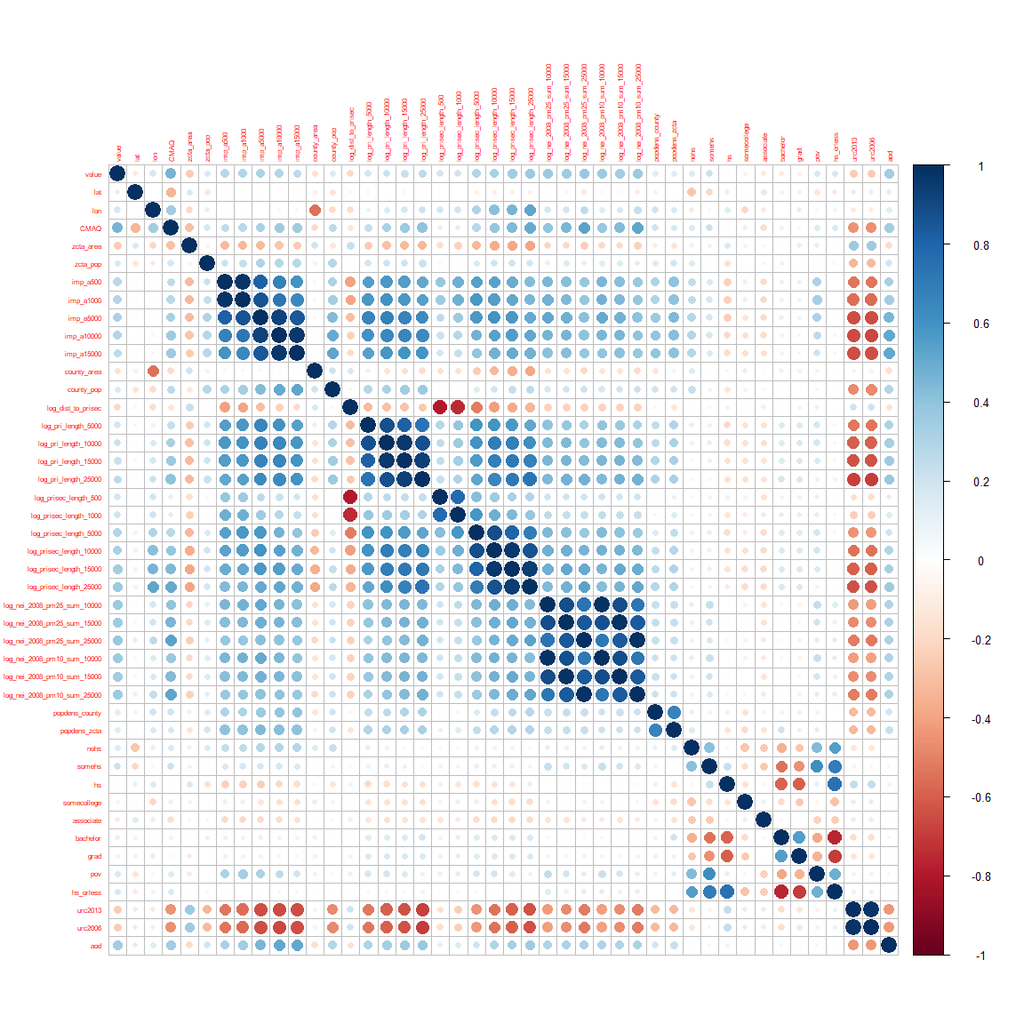

```r
PM_cor <- cor(pm %>% dplyr::select_if(is.numeric))
corrplot::corrplot(PM_cor, tl.cex = 0.5)
```

### split the data

tidymodels

```r
set.seed(1234)
pm_split <- rsample::initial_split(data = pm, prop = 2/3)
pm_split
```

```
<Analysis/Assess/Total>
<584/292/876>
```

Importantly the initial_split() function only determines what rows of our pm dataframe should be assigned for training or testing, it does not actually split the data.

To extract the testing and training data we can use the training() and testing() functions also of the rsample package.

```r
train_pm <-rsample::training(pm_split)
test_pm <-rsample::testing(pm_split)
```

### recipe

https://recipes.tidymodels.org/reference/index.html

```r
# library(tidymodels)
simple_rec <- train_pm %>%
  recipes::recipe(value ~ .)

simple_rec
```

```
Data Recipe

Inputs:
```

| role | #variables |
| --- | --- |
| outcome | 1 |
| predictor | 49 |

#### update role

of `id` which is not a predictor

```r
simple_rec <- train_pm %>%
  recipes::recipe(value ~ .) %>%
  recipes::update_role(id, new_role = "id variable")

simple_rec
```

```
Data Recipe

Inputs:
```

| role | #variables |
| --- | --- |
| id variable | 1 |
| outcome | 1 |
| predictor | 48 |

#### steps

https://recipes.tidymodels.org/reference/index.html

All of the step functions look like step_*() with the* replaced with a name, except for the check functions which look like check_*().

There are several ways to select what variables to apply steps to:

1. Using tidyselect methods: contains(), matches(), starts_with(), ends_with(), everything(), num_range()
2. Using the type: all_nominal(), all_numeric() , has_type()
3. Using the role: all_predictors(), all_outcomes(), has_role()
4. Using the name - use the actual name of the variable/variables of interest

> We want to dummy encode our categorical variables so that they are numeric as we plan to use a linear regression for our model.

We will use the one-hot encoding means that we do not simply encode our categorical variables numerically, as our numeric assignments can be interpreted by algorithms as having a particular rank or order. Instead, binary variables made of 1s and 0s are used to arbitrarily assign a numeric value that has no apparent order.

```r
simple_rec %>%
  step_dummy(state, county, city, zcta, one_hot = TRUE)
```

```
Data Recipe

Inputs:
```

| role | #variables |
| --- | --- |
| id variable | 1 |
| outcome | 1 |
| predictor | 48 |

```
Operations:

Dummy variables from state, county, city, zcta
```

```r
simple_rec %>%
  update_role("fips", new_role = "county id")
```

```
Data Recipe

Inputs:
```

| role | #variables |
| --- | --- |
| county id | 1 |
| id variable | 1 |
| outcome | 1 |
| predictor | 47 |

##### step_corr - remove redundant correlations

We also want to remove variables that appear to be redundant and are highly correlated with others, as we know from our exploratory data analysis that many of our variables are correlated with one another. We can do this using the step_corr() function.

```r
simple_rec %>%
  step_corr(all_predictors(), - CMAQ, - aod)
```

```
Data Recipe

Inputs:
```

| role | #variables |
| --- | --- |
| id variable | 1 |
| outcome | 1 |
| predictor | 48 |

```
Operations:

Correlation filter on all_predictors(), -CMAQ, -aod
```

##### step_nzv – remove variables with near-zero variance

```r
simple_rec %>%
  step_nzv(all_predictors(), - CMAQ, - aod)
```

```
Data Recipe

Inputs:
```

| role | #variables |
| --- | --- |
| id variable | 1 |
| outcome | 1 |
| predictor | 48 |

```
Operations:

Sparse, unbalanced variable filter on all_predictors(), -CMAQ, -aod
```

##### Putting it all together

```r
simple_rec <- train_pm %>%
  recipes::recipe(value ~ .) %>%
  recipes::update_role(id, new_role = "id variable") %>%
  update_role("fips", new_role = "county id") %>%
  step_dummy(state, county, city, zcta, one_hot = TRUE) %>%
  step_corr(all_predictors(), - CMAQ, - aod)%>%
  step_nzv(all_predictors(), - CMAQ, - aod)

simple_rec
```

```
Data Recipe

Inputs:
```

| role | #variables |
| --- | --- |
| county id | 1 |
| id variable | 1 |
| outcome | 1 |
| predictor | 47 |

```
Operations:

Dummy variables from state, county, city, zcta
Correlation filter on all_predictors(), -CMAQ, -aod
Sparse, unbalanced variable filter on all_predictors(), -CMAQ, -aod
```

#### Preprocessing

```r
prepped_rec <- prep(simple_rec, verbose = TRUE, retain = TRUE)
```

```
oper 1 step dummy [training]
oper 2 step corr [training]
```

```
oper 3 step nzv [training]
The retained training set is ~ 0.27 Mb  in memory.
```

##### bake

we retained our preprocessed training data (i.e. prep(retain=TRUE)), we can take a look at it by using the bake() function of the recipes package

requires the new_data = NULL argument when we are using the training data.

```r
preproc_train <- bake(prepped_rec, new_data = NULL)
glimpse(preproc_train)
```

```
Rows: 584
Columns: 38
$ id                          <fct> 17119.2009, 56039.1006, 55009.0005, 30031.0008, 42069.2006, 6063.1006, 41029.1001, 6071~
$ fips                        <fct> 17119, 56039, 55009, 30031, 42069, 6063, 41029, 6071, 19055, 26115, 56033, 39035, 6037,~
$ lat                         <dbl> 38.90308, 43.47808, 44.50729, 45.77278, 41.44278, 39.93710, 42.53611, 34.10002, 42.6008~
$ lon                         <dbl> -90.14317, -110.76118, -87.99344, -111.17750, -75.62306, -120.93882, -122.87500, -117.4~
$ CMAQ                        <dbl> 9.167594, 2.447283, 6.938970, 2.056367, 6.267811, 4.344805, 3.294533, 12.753308, 7.0553~
$ zcta_area                   <dbl> 108835425, 2092228669, 24737298, 619007855, 6236104, 262028573, 215917460, 44875990, 76~
$ zcta_pop                    <dbl> 32704, 15851, 30611, 27367, 5104, 5970, 10528, 95397, 491, 5753, 24558, 5586, 42399, 11~
$ imp_a500                    <dbl> 22.08737024, 3.43252595, 40.67301038, 0.27854671, 23.43744374, 0.00000000, 0.73269896, ~
$ imp_a15000                  <dbl> 6.9998911, 0.4902971, 11.6350822, 3.1278958, 7.0492390, 0.4163350, 2.2387589, 27.664498~
$ county_area                 <dbl> 1853347576, 10347983791, 1371938244, 6740934490, 1189006298, 6612350713, 7209356169, 51~
$ county_pop                  <dbl> 269282, 21294, 248007, 89513, 214437, 20007, 203206, 2035210, 17764, 152021, 29116, 128~
$ log_dist_to_prisec          <dbl> 4.826338, 7.938653, 5.421107, 6.429274, 6.906396, 7.962802, 7.081952, 6.801096, 8.57577~
$ log_pri_length_5000         <dbl> 8.721351, 8.517193, 10.174230, 9.895746, 10.427861, 8.529855, 8.517193, 10.570459, 8.51~
```

[output cut: 25 more lines]

###### extracting

```r
baked_test_pm <- recipes::bake(prepped_rec, new_data = test_pm)
glimpse(baked_test_pm)
```

```
Rows: 292
Columns: 38
$ id                          <fct> 1003.001, 1049.1003, 1073.1005, 1073.5002, 1097.0003, 1103.0011, 1117.0006, 1127.0002, ~
$ fips                        <fct> 1003, 1049, 1073, 1073, 1097, 1103, 1117, 1127, 4003, 4013, 4013, 4019, 4019, 4025, 402~
$ lat                         <dbl> 30.49800, 34.28763, 33.33111, 33.70472, 30.76994, 34.51873, 33.31293, 33.83278, 31.3492~
$ lon                         <dbl> -87.88141, -85.96830, -87.00361, -86.66917, -88.08753, -86.97694, -86.82110, -87.27250,~
$ CMAQ                        <dbl> 8.098836, 8.534772, 10.235612, 9.303766, 8.654895, 8.821748, 10.235612, 8.140101, 5.266~
$ zcta_area                   <dbl> 190980522, 203836235, 166239542, 150661846, 12304398, 182234536, 107636446, 129312323, ~
$ zcta_pop                    <dbl> 27829, 8300, 16140, 21725, 6106, 30545, 23020, 10424, 1021, 25042, 37275, 32998, 30929,~
$ imp_a500                    <dbl> 0.01730104, 5.78200692, 1.69765343, 1.48325792, 4.41522491, 0.00000000, 15.44290657, 0.~
$ imp_a15000                  <dbl> 1.4386207, 0.9730444, 4.3006226, 4.2529421, 7.7170777, 4.1801201, 7.9813363, 1.5108669,~
$ county_area                 <dbl> 4117521611, 2012662359, 2878192209, 2878192209, 3184223082, 1500476319, 2032960300, 204~
$ county_pop                  <dbl> 182265, 71109, 658466, 658466, 412992, 119490, 195085, 67023, 131346, 3817117, 3817117,~
$ log_dist_to_prisec          <dbl> 4.648181, 3.721489, 6.526896, 4.288260, 5.779170, 6.689449, 6.749289, 7.041732, 6.76090~
$ log_pri_length_5000         <dbl> 8.517193, 8.517193, 10.915066, 8.517193, 10.364272, 8.517193, 10.041166, 8.517193, 8.51~
```

[output cut: 25 more lines]

###### examine

```r
traincities <- train_pm %>% distinct(city)
testcities <- test_pm %>% distinct(city)

#get the number of cities that were different
dim(dplyr::setdiff(traincities, testcities))
```

```
[1] 371   1
```

```r
#get the number of cities that overlapped
dim(dplyr::intersect(traincities, testcities))
```

```
[1] 61  1
```

So, let’s go back to our pm dataset and modify the city variable to just be values of in a city or not in a city using the case_when() function of dplyr. This function allows you to vectorize multiple if_else() statements.

```r
pm %>% #count(city, sort = TRUE)
  mutate(city = case_when(city == "Not in a city" ~ "Not in a city",
                          city != "Not in a city" ~ "In a city")) %>%
  select(state, county, city)
```

| state | county | city |
| --- | --- | --- |
| Alabama | Baldwin | In a city |
| Alabama | Clay | In a city |
| Alabama | Colbert | In a city |
| Alabama | DeKalb | In a city |
| Alabama | Etowah | In a city |
| Alabama | Houston | In a city |
| Alabama | Jefferson | In a city |
| Alabama | Jefferson | Not in a city |
| Alabama | Jefferson | Not in a city |
| Alabama | Jefferson | In a city |

[output cut: 866 more lines]

##### redo

```r
pm <- pm %>%
  mutate(city = case_when(city == "Not in a city" ~ "Not in a city",
                          city != "Not in a city" ~ "In a city"))

set.seed(1234) # same seed as before
pm_split <-rsample::initial_split(data = pm, prop = 2/3)
pm_split
```

```
<Analysis/Assess/Total>
<584/292/876>
```

```r
 train_pm <-rsample::training(pm_split)
 test_pm <-rsample::testing(pm_split)
```

```r
novel_rec <-train_pm %>%
    recipe() %>%
    update_role(everything(), new_role = "predictor") %>%
    update_role(value, new_role = "outcome") %>%
    update_role(id, new_role = "id variable") %>%
    update_role("fips", new_role = "county id") %>%
    step_dummy(state, county, city, zcta, one_hot = TRUE) %>%
    step_corr(all_numeric()) %>%
    step_nzv(all_numeric())
```

Now we will check the preprocessed data again to see if we still have NA values

```r
prepped_rec <- prep(novel_rec, verbose = TRUE, retain = TRUE)
```

```
oper 1 step dummy [training]
oper 2 step corr [training]
```

```
oper 3 step nzv [training]
The retained training set is ~ 0.27 Mb  in memory.
```

```r
preproc_train <- bake(prepped_rec, new_data = NULL)
glimpse(preproc_train)
```

```
Rows: 584
Columns: 38
$ id                          <fct> 17119.2009, 56039.1006, 55009.0005, 30031.0008, 42069.2006, 6063.1006, 41029.1001, 6071~
$ value                       <dbl> 12.410909, 5.149153, 11.751882, 7.523333, 10.077364, 15.281356, 6.915517, 15.206250, 10~
$ fips                        <fct> 17119, 56039, 55009, 30031, 42069, 6063, 41029, 6071, 19055, 26115, 56033, 39035, 6037,~
$ lat                         <dbl> 38.90308, 43.47808, 44.50729, 45.77278, 41.44278, 39.93710, 42.53611, 34.10002, 42.6008~
$ lon                         <dbl> -90.14317, -110.76118, -87.99344, -111.17750, -75.62306, -120.93882, -122.87500, -117.4~
$ CMAQ                        <dbl> 9.167594, 2.447283, 6.938970, 2.056367, 6.267811, 4.344805, 3.294533, 12.753308, 7.0553~
$ zcta_area                   <dbl> 108835425, 2092228669, 24737298, 619007855, 6236104, 262028573, 215917460, 44875990, 76~
$ zcta_pop                    <dbl> 32704, 15851, 30611, 27367, 5104, 5970, 10528, 95397, 491, 5753, 24558, 5586, 42399, 11~
$ imp_a500                    <dbl> 22.08737024, 3.43252595, 40.67301038, 0.27854671, 23.43744374, 0.00000000, 0.73269896, ~
$ imp_a15000                  <dbl> 6.9998911, 0.4902971, 11.6350822, 3.1278958, 7.0492390, 0.4163350, 2.2387589, 27.664498~
$ county_area                 <dbl> 1853347576, 10347983791, 1371938244, 6740934490, 1189006298, 6612350713, 7209356169, 51~
$ county_pop                  <dbl> 269282, 21294, 248007, 89513, 214437, 20007, 203206, 2035210, 17764, 152021, 29116, 128~
$ log_dist_to_prisec          <dbl> 4.826338, 7.938653, 5.421107, 6.429274, 6.906396, 7.962802, 7.081952, 6.801096, 8.57577~
```

[output cut: 25 more lines]

```r
baked_test_pm <- recipes::bake(prepped_rec, new_data = test_pm)
```

```r
glimpse(baked_test_pm)
```

```
Rows: 292
Columns: 38
$ id                          <fct> 1003.001, 1049.1003, 1073.1005, 1073.5002, 1097.0003, 1103.0011, 1117.0006, 1127.0002, ~
$ value                       <dbl> 9.597647, 11.659091, 12.399355, 11.951948, 10.032110, 11.373729, 11.562712, 11.705833, ~
$ fips                        <fct> 1003, 1049, 1073, 1073, 1097, 1103, 1117, 1127, 4003, 4013, 4013, 4019, 4019, 4025, 402~
$ lat                         <dbl> 30.49800, 34.28763, 33.33111, 33.70472, 30.76994, 34.51873, 33.31293, 33.83278, 31.3492~
$ lon                         <dbl> -87.88141, -85.96830, -87.00361, -86.66917, -88.08753, -86.97694, -86.82110, -87.27250,~
$ CMAQ                        <dbl> 8.098836, 8.534772, 10.235612, 9.303766, 8.654895, 8.821748, 10.235612, 8.140101, 5.266~
$ zcta_area                   <dbl> 190980522, 203836235, 166239542, 150661846, 12304398, 182234536, 107636446, 129312323, ~
$ zcta_pop                    <dbl> 27829, 8300, 16140, 21725, 6106, 30545, 23020, 10424, 1021, 25042, 37275, 32998, 30929,~
$ imp_a500                    <dbl> 0.01730104, 5.78200692, 1.69765343, 1.48325792, 4.41522491, 0.00000000, 15.44290657, 0.~
$ imp_a15000                  <dbl> 1.4386207, 0.9730444, 4.3006226, 4.2529421, 7.7170777, 4.1801201, 7.9813363, 1.5108669,~
$ county_area                 <dbl> 4117521611, 2012662359, 2878192209, 2878192209, 3184223082, 1500476319, 2032960300, 204~
$ county_pop                  <dbl> 182265, 71109, 658466, 658466, 412992, 119490, 195085, 67023, 131346, 3817117, 3817117,~
$ log_dist_to_prisec          <dbl> 4.648181, 3.721489, 6.526896, 4.288260, 5.779170, 6.689449, 6.749289, 7.041732, 6.76090~
```

[output cut: 25 more lines]

Great, now we no longer have NA values!

##### specify the model

For our case, we are going to start our analysis with a linear regression but we will demonstrate how we can try different models.

```r
PM_model <- parsnip::linear_reg() # PM was used in the name for particulate matter
PM_model
```

```
Linear Regression Model Specification (regression)
```

OK. So far, all we have defined is that we want to use a linear regression… Let’s tell parsnip more about what we want.

```r
lm_PM_model <-
  PM_model  %>%
  parsnip::set_engine("lm")

lm_PM_model
```

```
Linear Regression Model Specification (regression)

Computational engine: lm
```

Here, we aim to predict the air pollution. You can do this with the set_mode() function of the parsnip package, by using either set_mode(“classification”) or set_mode(“regression”).

```r
lm_PM_model <-
  PM_model  %>%
  parsnip::set_engine("lm") %>%
  set_mode("regression")

lm_PM_model
```

```
Linear Regression Model Specification (regression)

Computational engine: lm
```

```r
PM_wflow <-workflows::workflow() %>%
           workflows::add_recipe(novel_rec) %>%
           workflows::add_model(lm_PM_model)
PM_wflow
```

```
== Workflow =================================================================================================================
Preprocessor: Recipe
Model: linear_reg()

-- Preprocessor -------------------------------------------------------------------------------------------------------------
3 Recipe Steps

* step_dummy()
* step_corr()
* step_nzv()

-- Model --------------------------------------------------------------------------------------------------------------------
Linear Regression Model Specification (regression)

Computational engine: lm
```

```r
PM_wflow_fit <- parsnip::fit(PM_wflow, data = train_pm)
PM_wflow_fit
```

```
== Workflow [trained] =======================================================================================================
Preprocessor: Recipe
Model: linear_reg()

-- Preprocessor -------------------------------------------------------------------------------------------------------------
3 Recipe Steps

* step_dummy()
* step_corr()
* step_nzv()

-- Model --------------------------------------------------------------------------------------------------------------------

Call:
stats::lm(formula = ..y ~ ., data = data)

Coefficients:
                (Intercept)                          lat                          lon                         CMAQ
                  2.282e+02                    3.211e-02                    2.572e-02                    2.648e-01
                  zcta_area                     zcta_pop                     imp_a500                   imp_a15000
                 -2.722e-10                    6.877e-06                    5.815e-04                    6.867e-03
                county_area                   county_pop           log_dist_to_prisec          log_pri_length_5000
                 -1.767e-11                   -1.705e-07                    1.107e-01                   -3.237e-01
       log_pri_length_25000        log_prisec_length_500       log_prisec_length_1000       log_prisec_length_5000
                  2.409e-01                    2.135e-01                    1.112e-01                    3.368e-01
    log_prisec_length_10000  log_nei_2008_pm10_sum_10000  log_nei_2008_pm10_sum_15000  log_nei_2008_pm10_sum_25000
                  2.542e-01                    1.310e-01                   -7.462e-02                    1.011e-01
             popdens_county                 popdens_zcta                         nohs                       somehs
                 -3.251e-05                   -3.646e-05                   -2.310e+00                   -2.302e+00
                         hs                  somecollege                    associate                     bachelor
                 -2.305e+00                   -2.316e+00                   -2.343e+00                   -2.320e+00
                       grad                          pov                    hs_orless                      urc2013
                 -2.327e+00                    9.427e-03                           NA                    2.641e-01
                        aod             state_California               state_Illinois           city_Not.in.a.city
                  2.643e-02                    3.306e+00                   -1.179e-01                    9.673e-02
```

##### assessing the model fit

```r
wflowoutput <- PM_wflow_fit %>%
  pull_workflow_fit() %>%
  broom::tidy()

wflowoutput
```

| term | estimate | std.error | statistic | p.value |
| --- | --- | --- | --- | --- |
| (Intercept) | 2.281558e+02 | 1.213359e+02 | 1.88036569 | 6.058742e-02 |
| lat | 3.211379e-02 | 2.427911e-02 | 1.32269187 | 1.864886e-01 |
| lon | 2.571588e-02 | 9.770730e-03 | 2.63193014 | 8.728957e-03 |
| CMAQ | 2.648144e-01 | 4.291099e-02 | 6.17125035 | 1.316906e-09 |
| zcta_area | -2.722218e-10 | 1.628713e-10 | -1.67139154 | 9.521422e-02 |
| zcta_pop | 6.876775e-06 | 5.798911e-06 | 1.18587341 | 2.361853e-01 |
| imp_a500 | 5.815044e-04 | 7.680001e-03 | 0.07571671 | 9.396721e-01 |
| imp_a15000 | 6.867141e-03 | 1.170259e-02 | 0.58680543 | 5.575756e-01 |
| county_area | -1.767238e-11 | 1.766733e-11 | -1.00028581 | 3.176129e-01 |
| county_pop | -1.705195e-07 | 9.290520e-08 | -1.83541419 | 6.698510e-02 |

[output cut: 26 more lines]

##### important

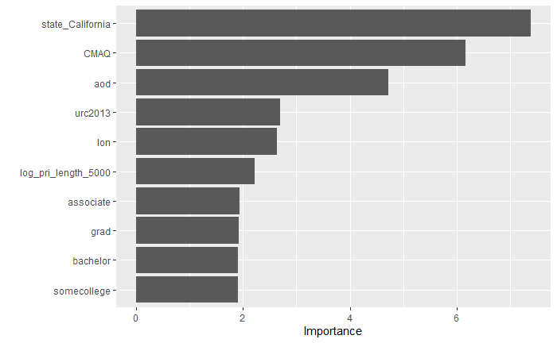

```r
PM_wflow_fit %>%
  pull_workflow_fit() %>%
  vip::vip(num_features = 10)
```